# Week 5 - Introduction to Data Analysis

ETC1010-5510

31 August, 2020

# Exercise 4: Exploring housing prices in Melbourne

#### **Estimated time: 25 min**

```r
library(tidyverse)
library(naniar)
library(simputation)
```

We are going to examine Melbourne house prices, using a data set available at https://www.kaggle.com/anthonypino/melbourne-housing-market). It was constructed by scraping the auction reports over several years, and adding more information on property details by scraping the web pages on the properties at domain.com.

```r
houses_raw <- read_csv("data/Melbourne_housing_FULL.csv.gz")
```

## Answer the following questions:

### Q1. Make an overview plot (e.g., vis_dat, vis_miss) of the full data. Which variables have missings?

[figure not shown]

```r
vis_miss(houses_raw)
```

The graph shows up empty because of limited RAM in RStudio Cloud. `vis_miss()` draws rectangle for each missing data point. This is what the plot actually looks like:

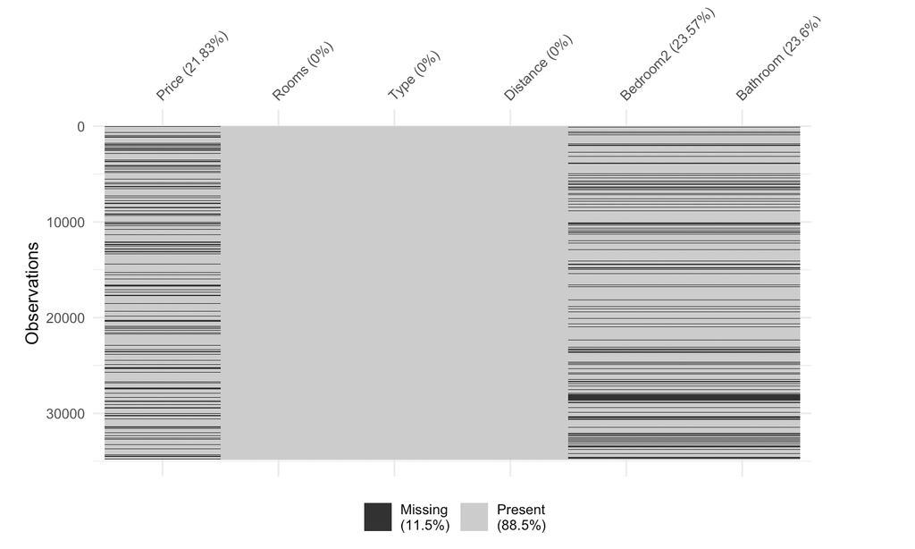

### Q2. Make a missing values summary of all the variables in the data. What proportion of observations are missing on Price?

```r
miss_var_summary(houses_raw)
```

```
## # A tibble: 6 x 3
##   variable n_miss pct_miss
##   <chr>     <int>    <dbl>
## 1 Bathroom   8226 23.6
## 2 Bedroom2   8217 23.6
## 3 Price      7610 21.8
## 4 Distance      1  0.00287
## 5 Rooms         0  0
## 6 Type          0  0
```

### Q3. Remove the observations that have missing values on Price, because this is the response variable that we want to ultimately predict. We can’t build a stable model for price if we don’t know the price.

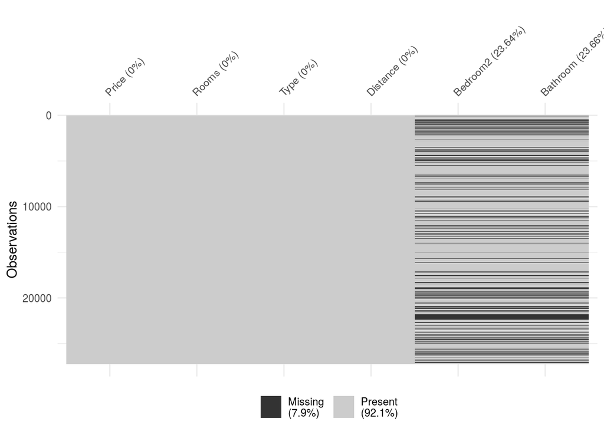

```r
houses <- houses_raw %>% filter(!is.na(Price))
vis_miss(houses)
```

### Q4. Make the tidy missing data for the houses data

```r
houses_shadow <- bind_shadow(houses)
houses_shadow
```

```
## # A tibble: 27,247 x 12
##     Price Rooms Type  Distance Bedroom2 Bathroom Price_NA Rooms_NA Type_NA
##     <dbl> <dbl> <chr>    <dbl>    <dbl>    <dbl> <fct>    <fct>    <fct>
##  1 1.48e6     2 h          2.5        2        1 !NA      !NA      !NA
##  2 1.03e6     2 h          2.5        2        1 !NA      !NA      !NA
##  3 1.46e6     3 h          2.5        3        2 !NA      !NA      !NA
##  4 8.50e5     3 h          2.5        3        2 !NA      !NA      !NA
##  5 1.60e6     4 h          2.5        3        1 !NA      !NA      !NA
##  6 9.41e5     2 h          2.5        2        1 !NA      !NA      !NA
##  7 1.88e6     3 h          2.5        4        2 !NA      !NA      !NA
##  8 1.64e6     2 h          2.5        2        1 !NA      !NA      !NA
##  9 1.00e6     3 h          2.5       NA       NA !NA      !NA      !NA
## 10 7.45e5     2 t          2.5       NA       NA !NA      !NA      !NA
## # … with 27,237 more rows, and 3 more variables: Distance_NA <fct>,
## #   Bedroom2_NA <fct>, Bathroom_NA <fct>
```

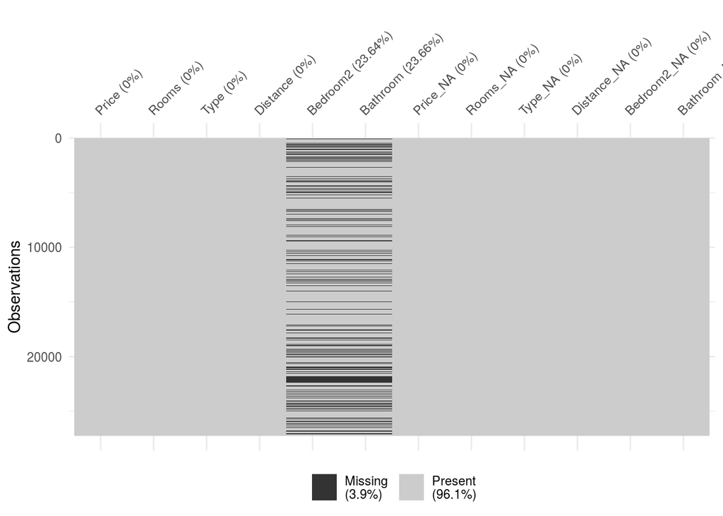

```r
vis_miss(houses_shadow)
```

### Q5. Plot Bathroom vs Bedroom2 coloured by missingness on Bedroom2. Why don’t any missing values show up?

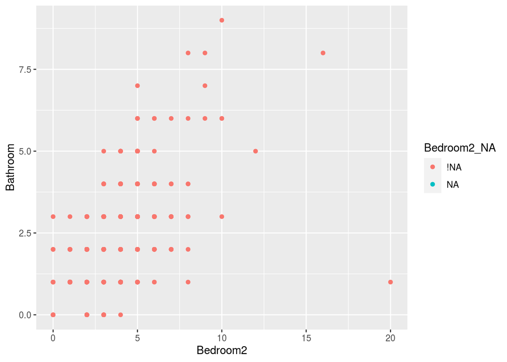

```r
ggplot(houses_shadow,
       aes(x = Bedroom2,
           y = Bathroom,
           colour = Bedroom2_NA)) +
  geom_point()
```

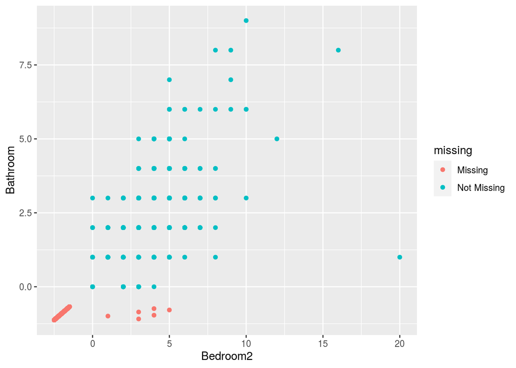

```r
#To see missing data:
ggplot(houses_shadow,
       aes(x = Bedroom2,
           y = Bathroom,)) +
    geom_miss_point()
```

### Q6. Impute the missing values for Bedroom2 and Bathroom, by using mean imputation.

```r
houses_imp_mean <- houses_shadow %>%
  mutate(Bedroom2 = impute_mean(Bedroom2),
         Bathroom = impute_mean(Bathroom)) %>%
  # identify where there were missings
  add_label_shadow()
houses_imp_mean
```

```
## # A tibble: 27,247 x 13
##     Price Rooms Type  Distance Bedroom2 Bathroom Price_NA Rooms_NA Type_NA
##     <dbl> <dbl> <chr>    <dbl>    <dbl>    <dbl> <fct>    <fct>    <fct>
##  1 1.48e6     2 h          2.5     2        1    !NA      !NA      !NA
##  2 1.03e6     2 h          2.5     2        1    !NA      !NA      !NA
##  3 1.46e6     3 h          2.5     3        2    !NA      !NA      !NA
##  4 8.50e5     3 h          2.5     3        2    !NA      !NA      !NA
##  5 1.60e6     4 h          2.5     3        1    !NA      !NA      !NA
##  6 9.41e5     2 h          2.5     2        1    !NA      !NA      !NA
##  7 1.88e6     3 h          2.5     4        2    !NA      !NA      !NA
##  8 1.64e6     2 h          2.5     2        1    !NA      !NA      !NA
##  9 1.00e6     3 h          2.5     3.05     1.59 !NA      !NA      !NA
## 10 7.45e5     2 t          2.5     3.05     1.59 !NA      !NA      !NA
## # … with 27,237 more rows, and 4 more variables: Distance_NA <fct>,
## #   Bedroom2_NA <fct>, Bathroom_NA <fct>, any_missing <chr>
```

### Q7. Make a plot of the two variables, Bedroom2 and Bathroom, colouring by imputed values. Describe the pattern that you see.

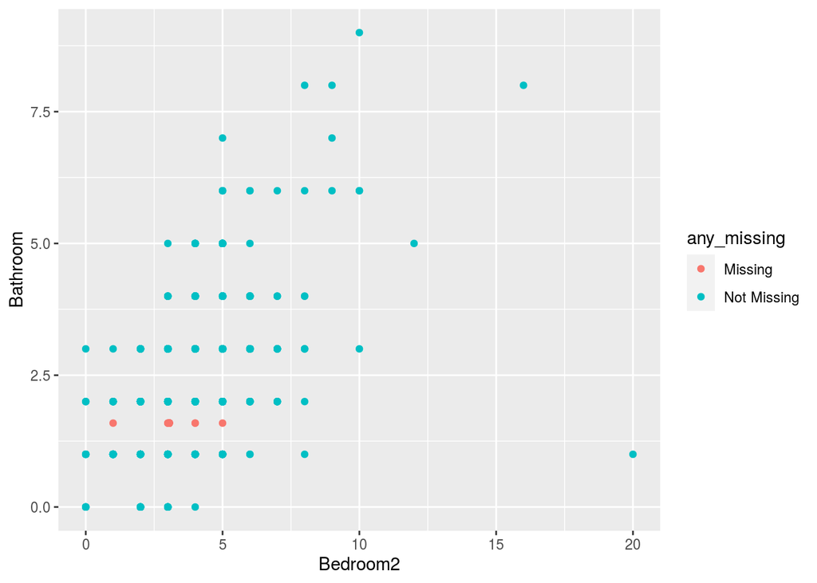

```r
ggplot(houses_imp_mean,
       aes(x = Bedroom2,
           y = Bathroom,
           colour = any_missing)) +
  geom_point()
```